# Lab exercise, week 3 - numpy & matplotlib basics

Contents:

- Overview of numpy arrays
- Exercises for numpy
- Exercises for plotting

## NumPy - overview

Python lists are somewhat weird creatures. In contrast to basic array types in other languages like C# and Java, they can hold objects of different types and new elements can be inserted in the middle. NumPy arrays are much more like C# arrays - all elements have the same type.

```python
# by convention numpy is always imported as np
import numpy as np
```

### Common ways of creating numpy arrays

```python
a = np.array([5, 2, 17])  # Convert a Python list into a numpy array
a
```

```
array([ 5,  2, 17])
```

```python
# List of lists gets converted into a 2D array
np.array([[5, 7, 2],
          [9, 4, 1]])
```

```
array([[5, 7, 2],
       [9, 4, 1]])
```

```python
np.arange(5)  # Same as Python's range() but creates a numpy array
```

```
array([0, 1, 2, 3, 4])
```

```python
np.zeros(5)  # Create a numpy array with five elements, all set to zero
```

```
array([0., 0., 0., 0., 0.])
```

```python
c = np.ones(7)  # Create a numpy array with five elements, all set to 1
c
```

```
array([1., 1., 1., 1., 1., 1., 1.])
```

```python
# Array of 6 random numbers between 0 and 1
np.random.rand(6)
```

```
array([0.90510041, 0.9838986 , 0.50457074, 0.80757753, 0.9604209 ,
       0.09986664])
```

```python
# array with 6 random integers between 0 and 100 (not including 100 as usual)
np.random.randint(100, size=6)
```

```
array([71, 17, 24, 83, 86, 70])
```

### Array properties

```python
b = np.array([[5, 7, 2],
              [9, 4, 1]])
b
```

```
array([[5, 7, 2],
       [9, 4, 1]])
```

```python
# Data type of the array
a.dtype
```

```
dtype('int64')
```

```python
# number of dimensions
b.ndim
```

```
2
```

```python
# array shape is a Python tuple, in this case it's (2, 3) because b is a 2 by 3 array.
b.shape
```

```
(2, 3)
```

```python
# The total number of elements
b.size
```

```
6
```

```python
# Note that zeros byt default uses the float64 data type
z = np.zeros(7)
z.dtype
```

```
dtype('float64')
```

```python
# But data type can be set explicitly, almost all numpy functions that create arrays take an optional dtype parameter
# Let's set it to an 8 bit integer
z = np.zeros(7, dtype=np.int8)
z.dtype
```

```
dtype('int8')
```

## Exercises

Read section 2.2 of the book (The Basics of NumPy Arrays) and complete the tasks below.

### Numpy Array Creation

##### Convert a list into a numpy array

```python
lst = [5, 3, 8, 4]
lst = np.array(lst)
lst
```

```
array([5, 3, 8, 4])
```

```python
# your code here
x = np.array([1, 2, 3, 4])
x
```

```
array([1, 2, 3, 4])
```

#### What happens when you multiply a list by 3, what a about an array multiplied by 3?

```python
# Feel free to add more cells
lst = [1, 2, 3, 4]
print(lst * 3)
lst = np.array(lst)
print(lst * 3)
```

```
[1, 2, 3, 4, 1, 2, 3, 4, 1, 2, 3, 4]
[ 3  6  9 12]
```

#### Create an array of 10 ones [1, 1, 1, ... ]

```python
ones = np.ones(10)
ones
```

```
array([1., 1., 1., 1., 1., 1., 1., 1., 1., 1.])
```

#### Create an array of 10 fives [5, 5, 5, .... ]

```python
fives = np.full(10, 5)
fives
```

```
array([5, 5, 5, 5, 5, 5, 5, 5, 5, 5])
```

#### Create an array of the integers from 10 to 50 (including 50)

```python
range_lst = np.arange(10, 51)
range_lst
```

```
array([10, 11, 12, 13, 14, 15, 16, 17, 18, 19, 20, 21, 22, 23, 24, 25, 26,
       27, 28, 29, 30, 31, 32, 33, 34, 35, 36, 37, 38, 39, 40, 41, 42, 43,
       44, 45, 46, 47, 48, 49, 50])
```

#### Create an array of 10 random numbers between 0 and 5

```python
rand_lst = np.random.randint(0, 5, 10)
rand_lst
```

```
array([1, 0, 3, 1, 2, 4, 1, 0, 2, 1])
```

#### Read the help for np.linspace function and create an array of 11 evenly spaced elements between 0 and 2

use `np.linspace?` or `?np.linspace` to show the help

```python
evenly_spaced = np.linspace(0, 2, num=11)
evenly_spaced
```

```
array([0. , 0.2, 0.4, 0.6, 0.8, 1. , 1.2, 1.4, 1.6, 1.8, 2. ])
```

#### Create a 3 by 4 array of ones

```python
one_matrix = np.ones((3, 4))
one_matrix
```

```
array([[1., 1., 1., 1.],
       [1., 1., 1., 1.],
       [1., 1., 1., 1.]])
```

#### Create a 3 by 4 array of fives

```python
five_matrix = np.full((3, 4), 5)
five_matrix
```

```
array([[5, 5, 5, 5],
       [5, 5, 5, 5],
       [5, 5, 5, 5]])
```

### Array Indexing

Using the following arrays `a` and `m` for the questions below

```python
a = np.arange(10,21)
a
```

```
array([10, 11, 12, 13, 14, 15, 16, 17, 18, 19, 20])
```

```python
m = np.arange(1,22).reshape((3,7))
m
```

```
array([[ 1,  2,  3,  4,  5,  6,  7],
       [ 8,  9, 10, 11, 12, 13, 14],
       [15, 16, 17, 18, 19, 20, 21]])
```

### Create an array containing...

#### the first 4 elements of a

```python
first_four = a[0:4]
first_four
```

```
array([10, 11, 12, 13])
```

#### the last 3 elements of a

```python
last_three = a[-3:]
last_three
```

```
array([18, 19, 20])
```

#### The middle elements of a from 15 to 18 inclusive

```python
middle_elements = a[5:9]
middle_elements
```

```
array([15, 16, 17, 18])
```

#### The first column of m

```python
first_col = m[:, 0]
first_col
```

```
array([ 1,  8, 15])
```

#### The middle row of m

```python
middle_row = m[1]
middle_row
```

```
array([ 8,  9, 10, 11, 12, 13, 14])
```

#### The left 3 columns of m

```python
left_three = m[:, 0:3]
left_three
```

```
array([[ 1,  2,  3],
       [ 8,  9, 10],
       [15, 16, 17]])
```

#### The bottom-right 2 by 2 square

```python
bottom_right = m[-2:, -2:]
bottom_right
```

```
array([[13, 14],
       [20, 21]])
```

#### Print every other element of a

Hint: use slicing with a step (`array[start:stop:step]`)

```python
every_other = a[::2]
every_other
```

```
array([10, 12, 14, 16, 18, 20])
```

#### Print the `even` elements of a

Hint: use boolean indexing

```python
even_elements = a[a % 2 == 0]
even_elements
```

```
array([10, 12, 14, 16, 18, 20])
```

### Array Math

#### Subtract 5 from each element of a

```python
minus_five = a - 5
minus_five
```

```
array([ 5,  6,  7,  8,  9, 10, 11, 12, 13, 14, 15])
```

#### Calculate the `sum` of all the elements in a

```python
a_sum = a.sum()
a_sum
```

```
np.int64(165)
```

#### Calculate the sum of each column and each row in `m`

Hint: use the `axis` argument of the `sum` method

```python
column_sum = m.sum(axis=0)
row_sum = m.sum(axis=1)
print(column_sum)
print(row_sum)
```

```
[24 27 30 33 36 39 42]
[ 28  77 126]
```

#### Create an array containing squares of all numbers from 1 to 10 (inclusive)

```python
squares = np.arange(1, 11) * np.arange(1, 11)
squares
```

```
array([  1,   4,   9,  16,  25,  36,  49,  64,  81, 100])
```

#### Create an array containing all powers of 2 from $2^0$ to $2^{10}$ (inclusive)

```python
powers = 2 ** np.arange(0, 11)
powers
```

```
array([   1,    2,    4,    8,   16,   32,   64,  128,  256,  512, 1024])
```

#### Same as above (powers of two), but subtract one from each element, that is $a_k = 2^k - 1$

```python
powers_minus = 2 ** np.arange(0, 11) - 1
powers_minus
```

```
array([   0,    1,    3,    7,   15,   31,   63,  127,  255,  511, 1023])
```

## Plotting Basics

- Use [this tutorial](https://matplotlib.org/users/pyplot_tutorial.html) as reference when (if) you get stuck
- Execute the cells with imports, otherwise you won't have numpy and matplotlib imported and Python will complain

```python
import numpy as np
import matplotlib.pyplot as plt
```

```python
# Load weather data (take a look at that CSV file on GitHub or via Excel and note column names)
weather = np.loadtxt("OshawaWeather2016.csv", skiprows=1, delimiter=',')
```

```python
weather.shape
```

```
(349, 5)
```

```python
weather.dtype
```

```
dtype('float64')
```

#### Crate separate 1D arrays for each column (e.g: day, maxt, mint and so on)

```python
# your code here
# column name in csv file: Day,Max Temp (°C),Min Temp (°C),Mean Temp (°C),Total Precip (mm)
# day = weather[???]
weather
day = weather[:,0]
maxt = weather[:,1]
mint = weather[:,2]
meant = weather[:,3]
total_precip = weather[:,4]
```

#### Plot the minimum temperature as a function of day number

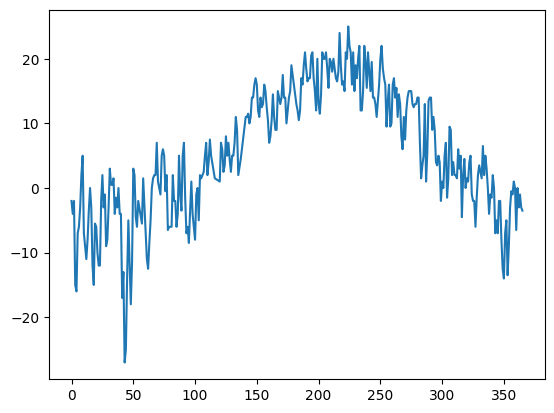

```python
plt.plot(day, mint)
```

#### Plot the max temperature in degrees Fahrenheit

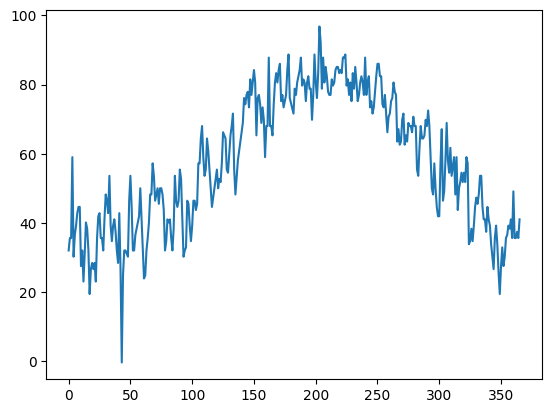

```python
plt.plot(day, maxt * 9 / 5 + 32)
```

#### Plot the difference between the maximum and the minimum day temperature as a function of day number

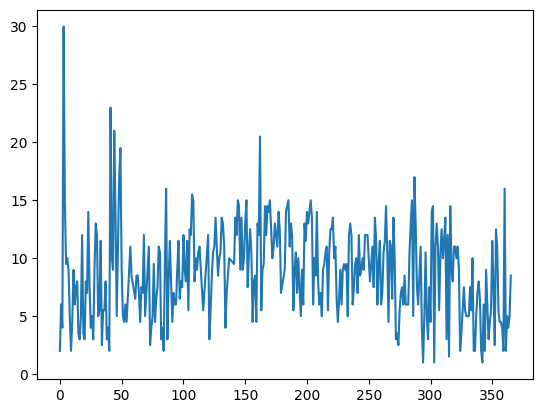

```python
plt.plot(day, maxt - mint)
```

#### Plot both, the minimum and maximum temperature on the same figure

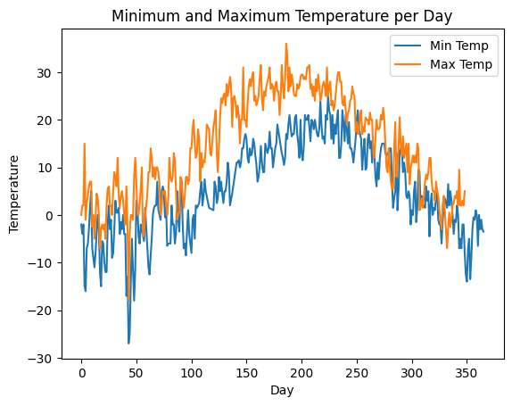

```python
plt.plot(day, mint, maxt)
plt.xlabel('Day')
plt.ylabel('Temperature')
plt.title('Minimum and Maximum Temperature per Day')
plt.legend(['Min Temp', 'Max Temp'])
```

#### Add axis labels and a legend to the plot above

Use the following functions:

- plt.xlabel
- plt.ylabel
- plt.title
- plt.legend

```python
plt.hist?
```

[output not shown]

[output cut: 168 more lines]

[output not shown]

#### Plot a histogram of the differences between the min and max temperature

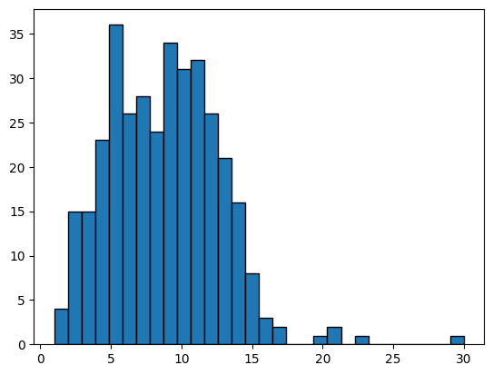

```python
plt.hist(maxt - mint, bins=30, edgecolor='black')
```

#### For each day calculate the average of the 3 temperatures in the data (min max and avg)

```python
avg = (mint + maxt + meant) / 3
avg
```

```
array([ -1.        ,  -1.        ,   0.        ,   0.        ,
        -8.5       ,  -2.26666667,  -1.        ,   1.5       ,
         4.5       ,   6.        ,  -4.76666667,  -4.5       ,
        -8.        ,  -4.26666667,   0.5       ,   1.76666667,
        -1.5       ,  -9.5       ,  -9.        ,  -3.76666667,
        -4.5       ,  -6.        ,  -8.5       ,  -5.        ,
         1.76666667,   4.        ,  -0.5       ,   0.5       ,
        -4.5       ,  -1.5       ,   3.        ,   5.5       ,
         3.26666667,   6.26666667,   2.76666667,  -1.26666667,
         1.26666667,   1.        ,   1.5       ,  -2.        ,
        -3.        ,  -5.5       ,  -8.        , -22.5       ,
       -14.5       ,  -7.        ,  -2.5       ,  -9.5       ,
        -1.76666667,   7.5       ,   4.5       ,  -2.26666667,
        -3.        ,   0.26666667,   0.        ,   5.76666667,
        -7.76666667,  -8.26666667,  -4.26666667,  -1.5       ,
         2.26666667,   5.26666667,   5.5       ,   8.        ,
         9.5       ,   4.5       ,   4.5       ,   6.26666667,
         8.        ,   7.5       ,   4.26666667,   4.26666667,
        -3.26666667,  -2.26666667,  -0.5       ,  -0.76666667,
         3.5       ,   0.        ,  -1.        ,  -1.26666667,
         4.        ,   6.5       ,   3.        ,   2.26666667,
         9.        ,   9.26666667,   2.        ,  -4.        ,
        -3.        ,  -4.        ,   2.26666667,   4.26666667,
         0.        ,  -2.26666667,  -2.        ,   3.5       ,
         4.        ,   0.76666667,   4.76666667,   7.76666667,
         8.        ,  10.26666667,  12.5       ,  11.        ,
         7.        ,   8.5       ,  12.76666667,  10.5       ,
         4.26666667,   7.        ,   8.5       ,   8.76666667,
         6.76666667,   8.76666667,  13.5       ,  11.76666667,
        12.5       ,   8.76666667,   7.5       ,  10.26666667,
        11.76666667,  13.5       ,  16.5       ,  11.        ,
         5.5       ,   9.5       ,  15.76666667,  17.76666667,
        17.5       ,  17.5       ,  18.26666667,  18.5       ,
        20.76666667,  20.5       ,  22.        ,  22.5       ,
        19.5       ,  14.76666667,  19.26666667,  18.76666667,
        18.26666667,  18.26666667,  19.        ,  16.76666667,
        12.76666667,  13.5       ,  14.        ,  20.76666667,
        17.26666667,  15.5       ,  13.76666667,  16.26666667,
        21.        ,  21.26666667,  20.        ,  21.5       ,
        23.76666667,  19.        ,  19.5       ,  16.5       ,
```

[output cut: 33 more lines]

```
        10.26666667,   7.        ,   7.76666667,   8.26666667,
         7.5       ,   9.        ,   5.76666667,   2.76666667,
         6.5       ,   8.5       ,   5.5       ,   7.        ,
         6.        ,   9.5       ,   9.5       ,   0.        ,
        -0.26666667,   0.76666667,  -2.26666667,   1.26666667,
         4.5       ,   6.        ,   5.        ,   5.26666667,
         9.26666667,   7.        ,   6.        ,   4.        ,
         2.5       ,  -0.5       ,   3.        ,   1.76666667,
         3.        ,   0.5       ,  -4.        ,  -4.        ,
        -2.5       ,   1.        ,  -0.5       ,  -5.76666667,
        -9.76666667,  -8.26666667,  -3.26666667,  -3.76666667,
        -7.26666667,  -3.5       ,  -0.26666667,   1.76666667,
         1.26666667,   3.        ,   1.        ,   1.5       ,
         1.        ,  -0.5       ,   1.        ,  -0.5       ,
         0.76666667])
```

#### Calculate the total amount of precipitation for the whole year

Does the number seem reasonable? The annual average precipitation in Toronto is 831 mm according to https://en.wikipedia.org/wiki/Geography_of_Toronto

```python
annual_precip = total_precip.sum()
annual_precip
```

```
np.float64(662.8000000000001)
```

#### Calculate the total precipitation on all odd numbered days (day 1, 3, 5 and so on)

```python
annual_odd_precip = total_precip[1::2].sum()
annual_odd_precip
```

```
np.float64(296.9)
```